# Phenome-environment wide sex differences in *NHANES*

Tomás González Zarzar  
12/20

## Main purpose

To identify environmental exposures that have differential effects between sexes/genders

## For example

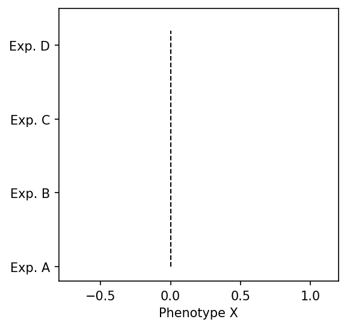

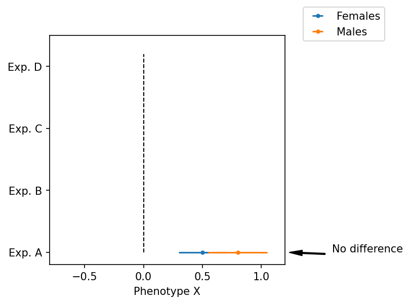

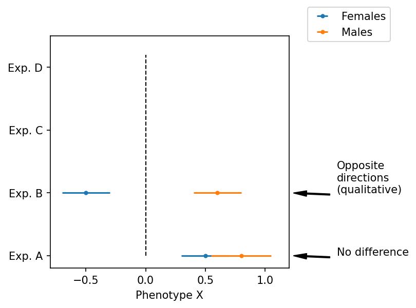

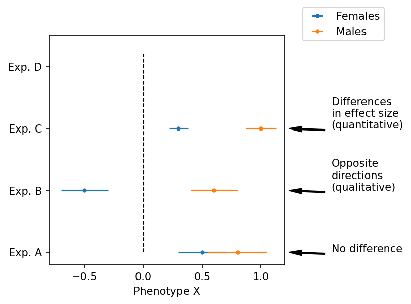

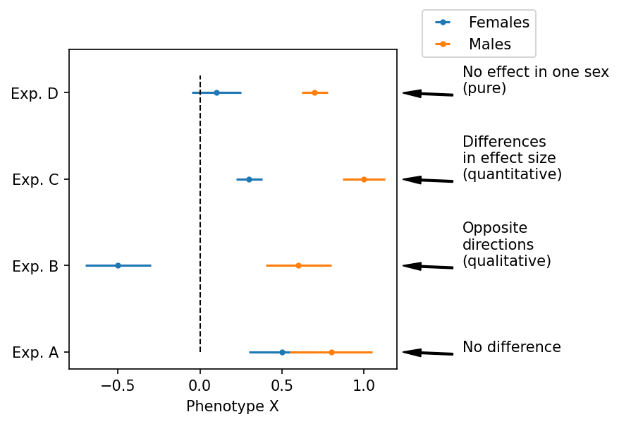

## Analysis plan

- QC process using Clarite and following Nikki's plan
- Divide in Replication and Discovery, and males and females each (4 cohorts)
- Normalize the variables to keep the $\beta$ coefficients consistent
- Successive EWAS models in each cohort with a different environment-phenotype pair, while controlling for covariates
- Based on previous research, meta-analyze the different cohorts (Winkler et al. 2017). That is, we end up with TWO cohorts, males and females

## Testing for differences

- To test for sex differences (comparison of two groups) we use the *difference test*:

$$ Z_{diff} = \frac{\beta_{1pq} - \beta_{2pq}}{\sqrt{se^2_{1pq} + se^2_{2pq}}} $$

## Finding qualitative differences

- Run the *difference test* across all exposure-phenotype tests
- Keep only those that are nominally significant ($p-value<0.05$) in both sexes and have opposite $\beta$ coefficients

## Finding pure and quantitative differences

- Filter by overall association (meta-analysis of male and female cohorts) with $\alpha = 0.05$
- From that selection, keep only those with a significant *difference test* using a Bonferroni corrected $\alpha$
- From the previous subset, classify those with $\beta$ coefficients in the same direction and nominally significant in both sexes as *quantitative*, and those nominally significant in only one sex as *pure*

## Exploratory analyses

```
There are 382 variables, and 9847 females and 9090 males
```

```
From the 382 variables, 53 are phenotypes, 8 are covariates, and 321 are exposures
```

## Correlations between phenotypes

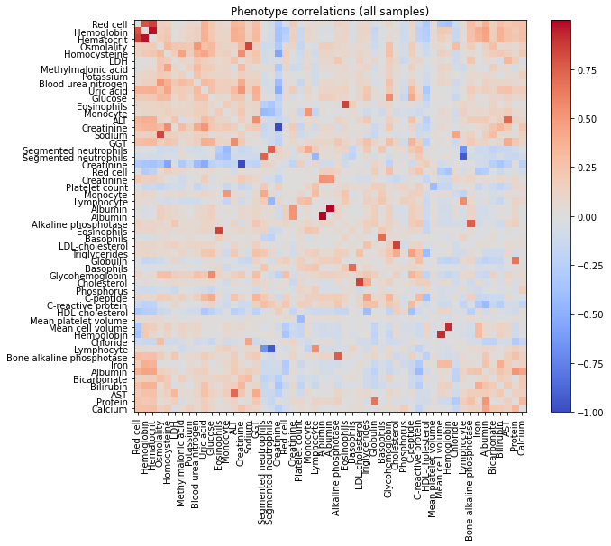

## Sex differences in correlations between phenotypes

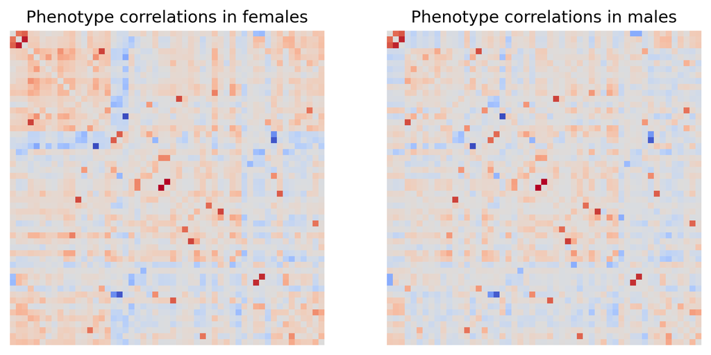

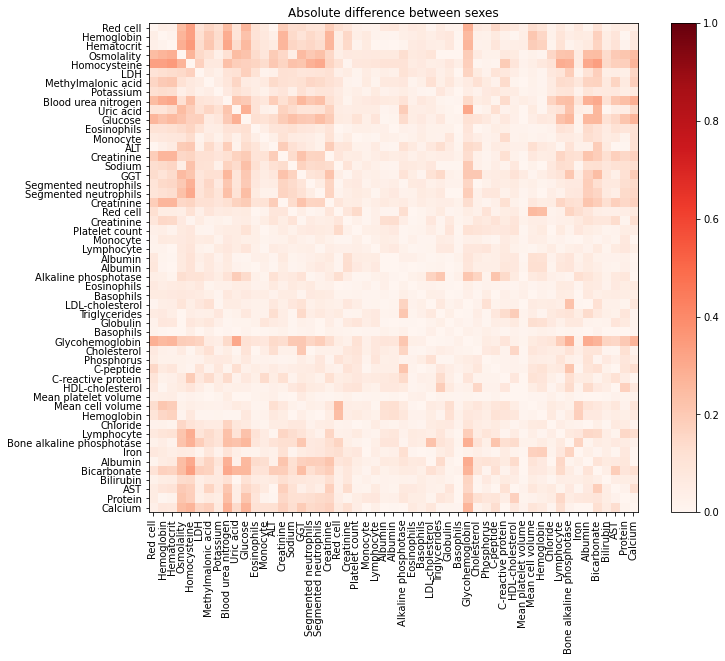

## Correlation between all variables

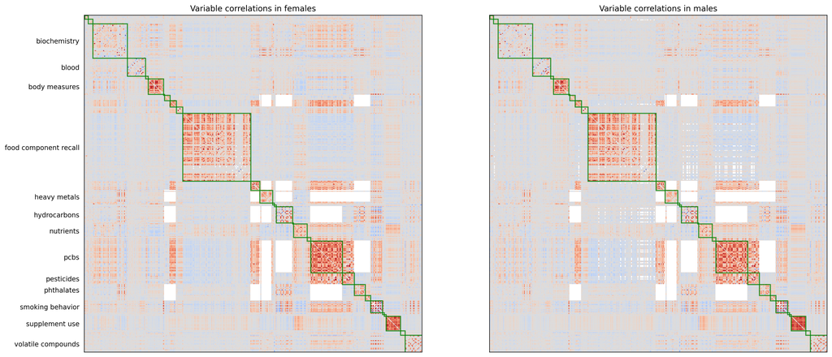

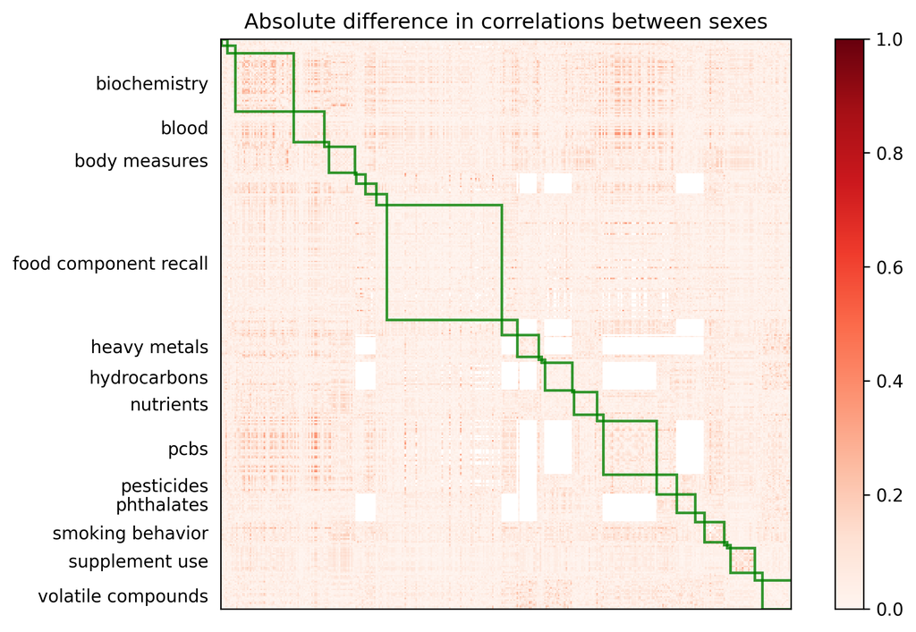

## Preliminary results

```
After the analysis, there are 11945 total tests
```

[output not shown]

[output not shown]

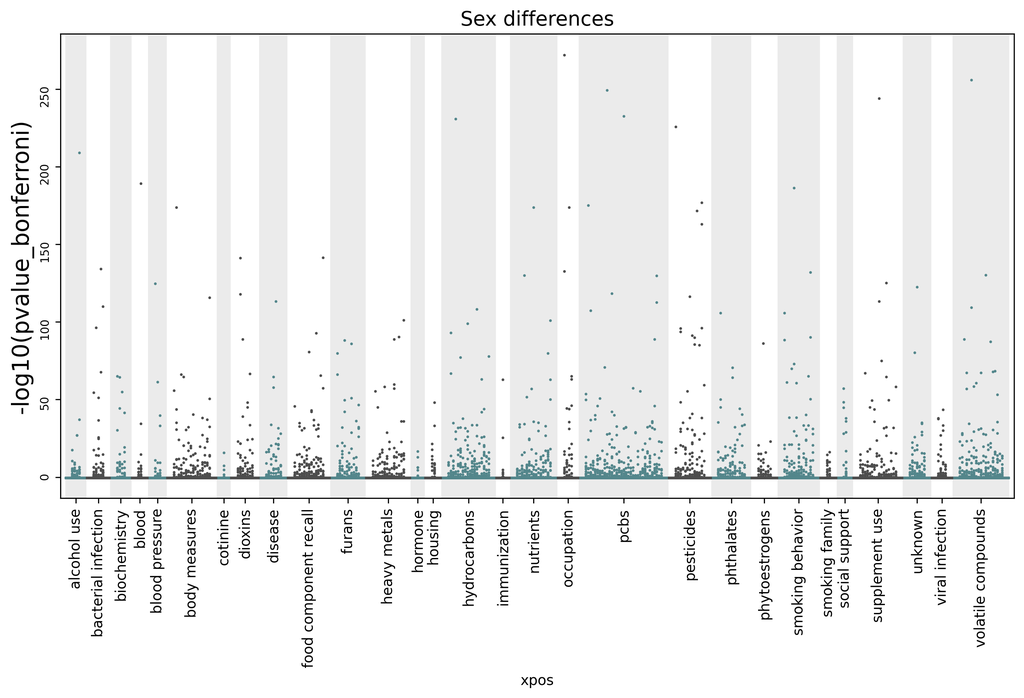

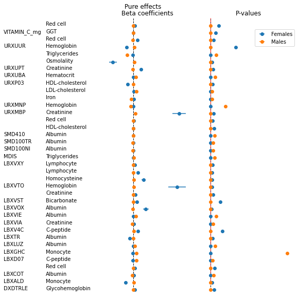

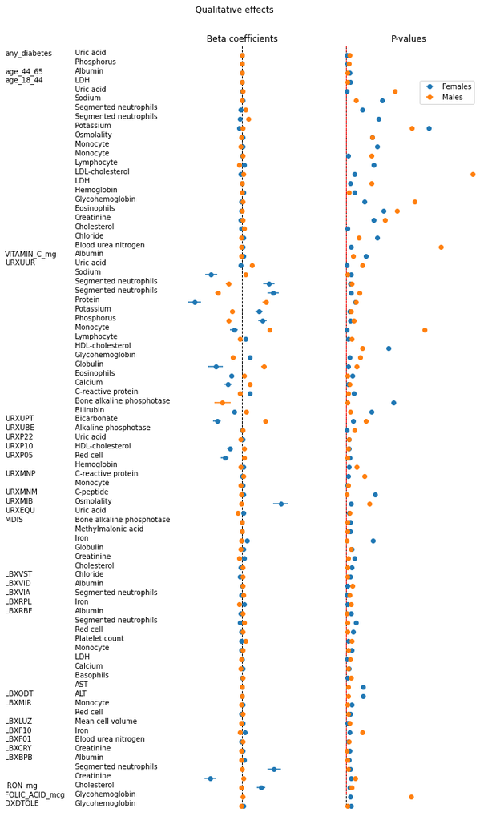

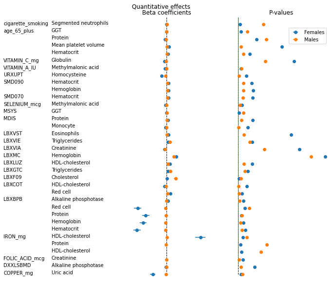

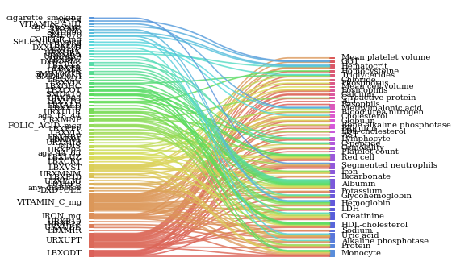

## References

- Winkler, Thomas W., Anne E. Justice, L. Adrienne Cupples, Florian Kronenberg, Zoltán Kutalik, Iris M. Heid, and GIANT consortium. 2017. “Approaches to Detect Genetic Effects That Differ between Two Strata in Genome-Wide Meta-Analyses: Recommendations Based on a Systematic Evaluation.” PloS One 12 (7): e0181038. https://doi.org/10/gbqbnm.